# Lab 6

### Repository Link

You can view the full project repository on [Github](https://github.com/DanielPelerman/GSB-544-Git/tree/main/Week%207/Lab%206)

**Note: Since the “Salary” variable represents annual salary in thousands of dollars, all numerical results and model coefficients in this report are interpreted in the same units (thousands of dollars).**

### Part 0: Data Cleaning

```python
import pandas as pd

df = pd.read_csv("~/Library/Mobile Documents/com~apple~CloudDocs/Main/Cal_Poly/Current_classes/GSB-544-Git/Week 7/Lab 6/Hitters.csv")

print(df.shape)
print(df.info())
```

```
(322, 20)
<class 'pandas.core.frame.DataFrame'>
RangeIndex: 322 entries, 0 to 321
Data columns (total 20 columns):
 #   Column     Non-Null Count  Dtype
---  ------     --------------  -----
 0   AtBat      322 non-null    int64
 1   Hits       322 non-null    int64
 2   HmRun      322 non-null    int64
 3   Runs       322 non-null    int64
 4   RBI        322 non-null    int64
 5   Walks      322 non-null    int64
 6   Years      322 non-null    int64
 7   CAtBat     322 non-null    int64
 8   CHits      322 non-null    int64
 9   CHmRun     322 non-null    int64
 10  CRuns      322 non-null    int64
 11  CRBI       322 non-null    int64
 12  CWalks     322 non-null    int64
 13  League     322 non-null    object
 14  Division   322 non-null    object
 15  PutOuts    322 non-null    int64
 16  Assists    322 non-null    int64
 17  Errors     322 non-null    int64
 18  Salary     263 non-null    float64
 19  NewLeague  322 non-null    object
dtypes: float64(1), int64(16), object(3)
memory usage: 50.4+ KB
None
```

Since some records have missing values for Salary, we cannot use them for prediction, so we remove them from the data frame. We are still left with a large number of records so this is okay.

```python
hitters = df.dropna(subset = ["Salary"])
print(hitters.info())
hitters.head()
```

```
<class 'pandas.core.frame.DataFrame'>
Index: 263 entries, 1 to 321
Data columns (total 20 columns):
 #   Column     Non-Null Count  Dtype
---  ------     --------------  -----
 0   AtBat      263 non-null    int64
 1   Hits       263 non-null    int64
 2   HmRun      263 non-null    int64
 3   Runs       263 non-null    int64
 4   RBI        263 non-null    int64
 5   Walks      263 non-null    int64
 6   Years      263 non-null    int64
 7   CAtBat     263 non-null    int64
 8   CHits      263 non-null    int64
 9   CHmRun     263 non-null    int64
 10  CRuns      263 non-null    int64
 11  CRBI       263 non-null    int64
 12  CWalks     263 non-null    int64
 13  League     263 non-null    object
 14  Division   263 non-null    object
 15  PutOuts    263 non-null    int64
 16  Assists    263 non-null    int64
 17  Errors     263 non-null    int64
 18  Salary     263 non-null    float64
 19  NewLeague  263 non-null    object
dtypes: float64(1), int64(16), object(3)
memory usage: 43.1+ KB
None
```

|  | AtBat | Hits | HmRun | Runs | RBI | Walks | Years | CAtBat | CHits | CHmRun | CRuns | CRBI | CWalks | League | Division | PutOuts | Assists | Errors | Salary | NewLeague |
| --- | --- | --- | --- | --- | --- | --- | --- | --- | --- | --- | --- | --- | --- | --- | --- | --- | --- | --- | --- | --- |
| 1 | 315 | 81 | 7 | 24 | 38 | 39 | 14 | 3449 | 835 | 69 | 321 | 414 | 375 | N | W | 632 | 43 | 10 | 475.000 | N |
| 2 | 479 | 130 | 18 | 66 | 72 | 76 | 3 | 1624 | 457 | 63 | 224 | 266 | 263 | A | W | 880 | 82 | 14 | 480.000 | A |
| 3 | 496 | 141 | 20 | 65 | 78 | 37 | 11 | 5628 | 1575 | 225 | 828 | 838 | 354 | N | E | 200 | 11 | 3 | 500.000 | N |
| 4 | 321 | 87 | 10 | 39 | 42 | 30 | 2 | 396 | 101 | 12 | 48 | 46 | 33 | N | E | 805 | 40 | 4 | 91.500 | N |
| 5 | 594 | 169 | 4 | 74 | 51 | 35 | 11 | 4408 | 1133 | 19 | 501 | 336 | 194 | A | W | 282 | 421 | 25 | 750.000 | A |

```python
import pandas as pd
import numpy as np
from sklearn.pipeline import Pipeline
from sklearn.compose import make_column_selector, ColumnTransformer
from sklearn.preprocessing import StandardScaler, OneHotEncoder, PolynomialFeatures
from sklearn.linear_model import LinearRegression, Ridge, Lasso, ElasticNet
from sklearn.model_selection import train_test_split, cross_val_score
from sklearn.metrics import r2_score
```

```python
X = hitters.drop(["Salary"], axis = 1)
y = hitters["Salary"]

ct = ColumnTransformer(
  [
    ("dummify",
    OneHotEncoder(sparse_output = False, handle_unknown='ignore'),
    make_column_selector(dtype_include=object)),
    ("standardize",
    StandardScaler(),
    make_column_selector(dtype_include=np.number))
  ],
  remainder = "passthrough"
).set_output(transform="pandas")

ct.fit(X)
ct.transform(X)
```

|  | dummify__League_A | dummify__League_N | dummify__Division_E | dummify__Division_W | dummify__NewLeague_A | dummify__NewLeague_N | standardize__AtBat | standardize__Hits | standardize__HmRun | standardize__Runs | ... | standardize__Years | standardize__CAtBat | standardize__CHits | standardize__CHmRun | standardize__CRuns | standardize__CRBI | standardize__CWalks | standardize__PutOuts | standardize__Assists | standardize__Errors |
| --- | --- | --- | --- | --- | --- | --- | --- | --- | --- | --- | --- | --- | --- | --- | --- | --- | --- | --- | --- | --- | --- |
| 1 | 0.000 | 1.000 | 0.000 | 1.000 | 0.000 | 1.000 | -0.603 | -0.596 | -0.529 | -1.206 | ... | 1.398 | 0.347 | 0.174 | -0.003 | -0.122 | 0.259 | 0.435 | 1.221 | -0.523 | 0.213 |
| 2 | 1.000 | 0.000 | 0.000 | 1.000 | 1.000 | 0.000 | 0.513 | 0.492 | 0.730 | 0.442 | ... | -0.901 | -0.453 | -0.410 | -0.076 | -0.415 | -0.200 | 0.010 | 2.109 | -0.254 | 0.820 |
| 3 | 0.000 | 1.000 | 1.000 | 0.000 | 0.000 | 1.000 | 0.628 | 0.736 | 0.959 | 0.402 | ... | 0.771 | 1.302 | 1.318 | 1.899 | 1.412 | 1.573 | 0.356 | -0.325 | -0.744 | -0.848 |
| 4 | 0.000 | 1.000 | 1.000 | 0.000 | 0.000 | 1.000 | -0.562 | -0.462 | -0.185 | -0.618 | ... | -1.110 | -0.991 | -0.960 | -0.698 | -0.948 | -0.881 | -0.862 | 1.841 | -0.544 | -0.697 |
| 5 | 1.000 | 0.000 | 0.000 | 1.000 | 1.000 | 0.000 | 1.295 | 1.358 | -0.872 | 0.755 | ... | 0.771 | 0.767 | 0.635 | -0.612 | 0.423 | 0.017 | -0.251 | -0.031 | 2.087 | 2.488 |
| ... | ... | ... | ... | ... | ... | ... | ... | ... | ... | ... | ... | ... | ... | ... | ... | ... | ... | ... | ... | ... | ... |
| 317 | 0.000 | 1.000 | 1.000 | 0.000 | 0.000 | 1.000 | 0.635 | 0.426 | -0.529 | 0.402 | ... | -0.483 | 0.020 | 0.130 | -0.454 | 0.054 | -0.060 | -0.464 | 0.123 | -0.758 | -0.848 |
| 318 | 1.000 | 0.000 | 1.000 | 0.000 | 1.000 | 0.000 | 0.601 | 0.625 | -0.757 | 0.834 | ... | 0.980 | 1.250 | 1.219 | -0.369 | 1.621 | 0.374 | 2.332 | 0.080 | 1.811 | 1.730 |
| 319 | 1.000 | 0.000 | 0.000 | 1.000 | 1.000 | 0.000 | 0.485 | 0.403 | -0.986 | 0.245 | ... | -0.274 | -0.420 | -0.447 | -0.759 | -0.436 | -0.736 | -0.434 | -0.908 | -0.040 | -0.242 |
| 320 | 1.000 | 0.000 | 1.000 | 0.000 | 1.000 | 0.000 | 1.152 | 0.803 | -0.300 | 1.187 | ... | 0.144 | 0.237 | 0.208 | 0.338 | 0.329 | 0.278 | 0.272 | 3.662 | 0.085 | 0.517 |
| 321 | 1.000 | 0.000 | 0.000 | 1.000 | 1.000 | 0.000 | 1.546 | 1.380 | -0.300 | 0.873 | ... | 0.771 | 0.986 | 1.136 | -0.478 | 1.252 | 0.082 | -0.043 | 0.420 | -0.793 | -0.848 |

263 rows × 22 columns

### Part I: Different Model Specs

#### Part A: Regression Without Regularization

```python
lr_pipeline = Pipeline(
  [("preprocessing", ct),
  ("linear_regression", LinearRegression())]
)

lr_pipeline_fitted = lr_pipeline.fit(X, y)
lr_pipeline_fitted

# Access model and feature names
model = lr_pipeline_fitted.named_steps["linear_regression"]
feature_names = lr_pipeline_fitted.named_steps["preprocessing"].get_feature_names_out()

# Combine into a DataFrame
coef_table = pd.DataFrame({
    "Feature": feature_names,
    "Coefficient": model.coef_
}).sort_values(by="Coefficient", ascending=False).reset_index(drop=True)

# Display
print("Intercept:", model.intercept_)
coef_table
```

```
Intercept: 537.9273144423057
```

|  | Feature | Coefficient |
| --- | --- | --- |
| 0 | standardize__CRuns | 480.747 |
| 1 | standardize__Hits | 337.830 |
| 2 | standardize__CRBI | 260.690 |
| 3 | standardize__Walks | 135.074 |
| 4 | standardize__CHits | 86.688 |
| 5 | standardize__PutOuts | 78.761 |
| 6 | dummify__Division_E | 58.425 |
| 7 | standardize__Assists | 53.732 |
| 8 | standardize__HmRun | 37.854 |
| 9 | dummify__League_N | 31.300 |
| 10 | dummify__NewLeague_A | 12.381 |
| 11 | dummify__NewLeague_N | -12.381 |
| 12 | standardize__CHmRun | -14.182 |
| 13 | standardize__Years | -16.693 |
| 14 | standardize__Errors | -22.161 |
| 15 | standardize__RBI | -26.995 |
| 16 | dummify__League_A | -31.300 |
| 17 | dummify__Division_W | -58.425 |
| 18 | standardize__Runs | -60.572 |
| 19 | standardize__CWalks | -213.892 |
| 20 | standardize__AtBat | -291.095 |
| 21 | standardize__CAtBat | -391.039 |

**Coefficient Interpretation:**  
**Biggest 3:**  
**1. Career Runs (`standardize__CRuns` = 480.75):** A one standard deviation increase in a player’s career runs is associated with an estimated 480-point increase in salary, holding all other factors constant.  
This implies that players who have scored more runs over their careers tend to earn substantially  
higher salaries, reflecting the strong value placed on long-term offensive success.  
**2. Hits (`standardize__Hits` = 337.83):** A one standard deviation increase in the number of hits during the 1986 season corresponds to about a 338-point increase in salary.  
This suggests that recent, high-level performance in the most recent season has a large impact on  
pay; teams reward players who are currently performing well.  
**3. Career RBI’s (`standardize__CRBI` = 260.69):** A one standard deviation increase in a player’s career runs batted in (RBIs) is linked to an estimated 261-point increase in salary.  
This shows that cumulative offensive productivity (helping score runs for the team) is another key  
determinant of player value.

**Lowest 2:**  
**4. Career At-Bats (`standardize__CAtBat` = -391.04):** A one standard deviation increase in career at-bats is associated with roughly a 391-point decrease in salary, holding other variables constant.  
While this may seem counterintuitive, it likely reflects that players who have had many at-bats but  
relatively fewer runs or hits may be less efficient hitters — indicating longevity without elite productivity.  
**5. At-Bats (`standardize__AtBat` = -291.1):** Similarly, players with more at-bats during the 1986 season tend to have lower predicted salaries, after controlling for performance measures like hits and RBIs.  
This could suggest that simply having more opportunities to bat doesn’t necessarily translate to higher  
pay; it’s the quality of performance (Hits, RBIs) rather than quantity of appearances that matters.

```python
import warnings
warnings.filterwarnings("ignore", category=RuntimeWarning)

mse_scores = cross_val_score(
    lr_pipeline,
    X,
    y,
    cv = 5,
    scoring = 'neg_mean_squared_error')

mse_scores = -mse_scores

mean_mse = np.mean(mse_scores)


print("Cross-validated MSEs for each fold:", mse_scores)
print(f"\nExpected MSE for predicted 1989 Salaries: {mean_mse:.3f}")
```

```
Cross-validated MSEs for each fold: [ 76408.91409134 129937.76968228  79976.48830477 204818.01839674
 114540.36111572]

Expected MSE for predicted 1989 Salaries: 121136.310
```

#### Part B: Ridge Regression

```python
from sklearn.model_selection import GridSearchCV

# Define pipeline
ridge_pipeline = Pipeline([
    ("preprocessing", ct),
    ("ridge_regression", Ridge())
])

# Define range of alphas to tune
alphas = {'ridge_regression__alpha': np.array([100, 10, 1, 0.1, 0.001])}

# Grid search for best alpha
gscv = GridSearchCV(
    ridge_pipeline,
    param_grid=alphas,
    cv=5,
    scoring='neg_mean_squared_error',
)


# Fit model
gscv_fitted = gscv.fit(X, y)

best_model = gscv_fitted.best_estimator_

# Access final Ridge model and feature names
ridge_model = best_model.named_steps["ridge_regression"]
feature_names = best_model.named_steps["preprocessing"].get_feature_names_out()

# Create coefficient table
coef_table = pd.DataFrame({
    "Feature": feature_names,
    "Coefficient": ridge_model.coef_
}).sort_values(by="Coefficient", ascending=False).reset_index(drop=True)

# Display best alpha, intercept and coefficients
print("Best alpha:", gscv_fitted.best_params_['ridge_regression__alpha'])
print("\nIntercept:", round(ridge_model.intercept_, 3))
display(coef_table)

best_mse = -gscv_fitted.best_score_  # convert back to positive MSE
print("Expected MSE for predicted 1989 Salaries:", round(best_mse, 3))
```

```
Best alpha: 1.0

Intercept: 537.856
```

|  | Feature | Coefficient |
| --- | --- | --- |
| 0 | standardize__CRuns | 320.412 |
| 1 | standardize__Hits | 296.645 |
| 2 | standardize__CRBI | 160.387 |
| 3 | standardize__CHits | 126.660 |
| 4 | standardize__Walks | 124.407 |
| 5 | standardize__PutOuts | 78.624 |
| 6 | dummify__Division_E | 60.016 |
| 7 | standardize__Assists | 47.463 |
| 8 | standardize__CHmRun | 39.071 |
| 9 | dummify__League_N | 30.439 |
| 10 | standardize__HmRun | 18.101 |
| 11 | dummify__NewLeague_A | 13.111 |
| 12 | standardize__RBI | -9.113 |
| 13 | dummify__NewLeague_N | -13.111 |
| 14 | standardize__Errors | -23.724 |
| 15 | standardize__Runs | -29.339 |
| 16 | dummify__League_A | -30.439 |
| 17 | standardize__Years | -38.668 |
| 18 | dummify__Division_W | -60.016 |
| 19 | standardize__CWalks | -184.424 |
| 20 | standardize__CAtBat | -225.407 |
| 21 | standardize__AtBat | -270.686 |

```
Expected MSE for predicted 1989 Salaries: 119144.433
```

**Coefficient Interpretation:**  
**Biggest 3:**  
**1. Career Runs (`standardize__CRuns` = 320.41):** A one standard deviation increase in a player’s career runs is associated with an estimated 320-point increase in salary, holding other factors constant.  
This implies that players with stronger long-term offensive records tend to earn significantly higher  
salaries, underscoring the lasting importance of cumulative career performance.  
**2. Hits (`standardize__Hits` = 296.65):** A one standard deviation increase in the number of hits during the 1986 season corresponds to about a 297-point increase in salary.  
This suggests that recent, strong seasonal performance continues to play a major role in salary  
determination; teams reward players currently demonstrating high productivity.  
**3. Career RBI’s (`standardize__CRBI` = 160.39):** A one standard deviation increase in career runs batted in (RBIs) is associated with a 160-point increase in salary.  
This shows that consistent offensive contributions throughout a player’s career remain a key  
determinant of player value.

**Lowest 2:**  
**4. Career At-Bats (`standardize__CAtBat` = -225.41):** A one standard deviation increase in career at-bats corresponds to roughly a 225-point decrease in salary, holding all other variables constant.  
This may indicate that players who have had many opportunities to bat but fewer achievements (in runs or hits) are viewed as less efficient, suggesting longevity without high performance does not  
necessarily lead to higher pay.  
**5. At-Bats (`standardize__AtBat` = -270.69):** Players with more at-bats during the 1986 season tend to have lower predicted salaries, after controlling for other performance indicators.  
This implies that simply appearing more often at the plate does not equate to higher value—teams  
place greater emphasis on productivity (hits, RBIs, and runs) rather than the number of attempts.

#### Part C: Lasso Regression

```python
pd.set_option("display.float_format", "{:.3f}".format)

# Define pipeline
lasso_pipeline = Pipeline([
    ("preprocessing", ct),
    ("lasso_regression", Lasso(max_iter=10000))
])

# Define alpha range for tuning
alphas = {'lasso_regression__alpha': np.array([100, 10, 1, 0.1, 0.01])}

# Grid search with 5-fold CV
gscv = GridSearchCV(
    lasso_pipeline,
    param_grid=alphas,
    cv=5,
    scoring='neg_mean_squared_error',
)

# Fit model
gscv_fitted = gscv.fit(X, y)

# Get best model
best_model = gscv_fitted.best_estimator_

print("Best alpha:", gscv_fitted.best_params_['lasso_regression__alpha'])

# Access final Lasso model and feature names
lasso_model = best_model.named_steps["lasso_regression"]
feature_names = best_model.named_steps["preprocessing"].get_feature_names_out()

# Create coefficient table
coef_table = pd.DataFrame({
    "Feature": feature_names,
    "Coefficient": lasso_model.coef_
}).sort_values(by="Coefficient", ascending=False).reset_index(drop=True).round(3)

# Display intercept and coefficient table
print("\nIntercept:", lasso_model.intercept_)
display(coef_table)

best_mse = -gscv_fitted.best_score_  # convert back to positive MSE
print("Expected MSE for predicted 1989 Salaries:", round(best_mse, 3))
```

```
Best alpha: 1.0

Intercept: 498.74167424808866
```

|  | Feature | Coefficient |
| --- | --- | --- |
| 0 | standardize__CRuns | 375.566 |
| 1 | standardize__Hits | 304.360 |
| 2 | standardize__CRBI | 192.611 |
| 3 | standardize__Walks | 120.695 |
| 4 | dummify__Division_E | 114.413 |
| 5 | standardize__PutOuts | 78.760 |
| 6 | standardize__Assists | 41.997 |
| 7 | standardize__CHmRun | 14.226 |
| 8 | standardize__HmRun | 11.127 |
| 9 | dummify__League_N | 0.000 |
| 10 | dummify__NewLeague_A | 0.000 |
| 11 | dummify__NewLeague_N | -0.000 |
| 12 | standardize__RBI | -0.000 |
| 13 | standardize__CHits | 0.000 |
| 14 | dummify__Division_W | -0.000 |
| 15 | standardize__Errors | -18.479 |
| 16 | standardize__Runs | -24.967 |
| 17 | standardize__Years | -34.948 |
| 18 | dummify__League_A | -35.826 |
| 19 | standardize__CAtBat | -162.640 |
| 20 | standardize__CWalks | -189.645 |
| 21 | standardize__AtBat | -282.371 |

```
Expected MSE for predicted 1989 Salaries: 119758.109
```

**Coefficient Interpretation:**  
**Biggest 3:**  
**1. Career Runs (`standardize__CRuns` = 375.57):** A one standard deviation increase in a player’s career runs is associated with roughly a $376 higher salary, holding other factors constant.  
This shows that players with strong long-term offensive records earn substantially higher salaries;  
career scoring ability is highly valued.  
**2. Hits (`standardize__Hits` = 304.36):** Players who recorded more hits during the 1986 season tend to earn higher salaries, with a one-SD increase linked to about a $304 rise.  
This reflects the importance of recent batting performance; current success at the plate remains a  
major determinant of pay.  
**3. Career RBI’s (`standardize__CRBI` = 192.61):** Each standard-deviation increase in career runs batted in (CRBIs) is tied to about a $193 salary increase.  
This underscores how long-term productivity in driving in runs translates into higher compensation,  
further reinforcing the importance of cumulative career performance.

**Lowest 2:**  
**4. At-Bats (`standardize__AtBat` = -282.37):** A one–SD increase in at-bats is associated with a roughly $282 decrease in predicted salary, controlling for other stats.  
This negative sign could indicate that players who accumulate many at-bats without corresponding  
high run or hit totals may be seen as less efficient offensive contributors; suggesting quantity  
doesn’t equal quality.  
**5. Career Walks (`standardize__CWalks` = -189.65):** A one–SD increase in career walks predicts about a $190 lower salary, which is somewhat counterintuitive.  
It may reflect multicollinearity (since walks correlate with other batting stats) or the model’s attempt to  
shrink correlated predictors; Lasso penalizes redundant variables more heavily, sometimes pushing  
their influence downward.

**Coefficients = 0**  
Variables with coefficients exactly 0 (e.g., League_N, NewLeague_A, RBI, CHits) were removed from the model by the Lasso penalty.  
Meaning:  
Lasso applies L1 regularization, which not only shrinks coefficients but can set some of them exactly to zero, effectively performing feature selection. This tells us those variables do not add unique predictive value once stronger, correlated features (like CRuns, Hits, and CRBI) are already in the model.

#### Part D: Elastic-Net

```python
import warnings
from sklearn.exceptions import ConvergenceWarning

warnings.filterwarnings("ignore", category=ConvergenceWarning)

from sklearn.linear_model import ElasticNet
pd.set_option("display.float_format", "{:.3f}".format)

# Define pipeline
elastic_pipeline = Pipeline([
    ("preprocessing", ct),
    ("elastic_net", ElasticNet(max_iter=10000))
])

# Define parameter grid for alpha (strength) and l1_ratio (balance)
param_grid = {
    "elastic_net__alpha": [0.001, 0.01, 0.1, 1, 10, 100],
    "elastic_net__l1_ratio": np.arange(0.0, 1.2, 0.2)  # 0 = Ridge, 1 = Lasso
}

# Grid search with 5-fold CV using MSE
gscv = GridSearchCV(
    elastic_pipeline,
    param_grid=param_grid,
    cv=5,
    scoring='neg_mean_squared_error',
    return_train_score=True
)

# Fit model
gscv_fitted = gscv.fit(X, y)

# Get best model
best_model = gscv_fitted.best_estimator_

# Report results
best_alpha = gscv_fitted.best_params_['elastic_net__alpha']
best_l1 = gscv_fitted.best_params_['elastic_net__l1_ratio']
best_mse = -gscv_fitted.best_score_

print("Best alpha:", best_alpha)
print("Best l1_ratio:", best_l1)
print("Expected MSE for predicted 1989 Salaries:", round(best_mse, 3))

# Access final Elastic Net model and feature names
elastic_model = best_model.named_steps["elastic_net"]
feature_names = best_model.named_steps["preprocessing"].get_feature_names_out()

# Create coefficient table
coef_table = pd.DataFrame({
    "Feature": feature_names,
    "Coefficient": elastic_model.coef_
}).sort_values(by="Coefficient", ascending=False).reset_index(drop=True).round(3)

# Display intercept and coefficients
print("\nIntercept:", elastic_model.intercept_)
display(coef_table)
```

```
Best alpha: 0.01
Best l1_ratio: 0.0
Expected MSE for predicted 1989 Salaries: 118957.969

Intercept: 537.8437436091397
```

|  | Feature | Coefficient |
| --- | --- | --- |
| 0 | standardize__Hits | 249.933 |
| 1 | standardize__CRuns | 226.829 |
| 2 | standardize__CHits | 123.652 |
| 3 | standardize__CRBI | 122.933 |
| 4 | standardize__Walks | 111.868 |
| 5 | standardize__PutOuts | 77.976 |
| 6 | dummify__Division_E | 60.813 |
| 7 | standardize__CHmRun | 55.647 |
| 8 | standardize__Assists | 41.455 |
| 9 | dummify__League_N | 29.056 |
| 10 | dummify__NewLeague_A | 12.395 |
| 11 | standardize__HmRun | 5.367 |
| 12 | standardize__RBI | 1.909 |
| 13 | standardize__Runs | -6.953 |
| 14 | dummify__NewLeague_N | -12.395 |
| 15 | standardize__Errors | -24.754 |
| 16 | dummify__League_A | -29.056 |
| 17 | standardize__Years | -49.514 |
| 18 | dummify__Division_W | -60.813 |
| 19 | standardize__CAtBat | -122.141 |
| 20 | standardize__CWalks | -156.494 |
| 21 | standardize__AtBat | -233.289 |

**Coefficient Interpretation:**  
**Biggest 3:**  
**1. Hits (`standardize__Hits` = 249.93):** A one standard deviation increase in season hits is associated with about a $250 increase in salary, holding other variables constant.  
This emphasizes that strong recent offensive performance, successfully hitting the ball and getting on base, remains one of the biggest salary drivers.  
**2. Career Runs (`standardize__CRuns` = 226.83):** Players who have accumulated more career runs scored tend to earn higher salaries, with each one–SD increase tied to about a $227 increase in salary.  
This underscores the importance of sustained offensive contributions over a player’s career; long-term productivity pays off.  
**3. Career Hits (`standardize__CHits` = 123.65):** A one–SD rise in career hits corresponds to about a $124 increase in salary.  
Like career runs, this shows that consistency and proven performance across seasons heavily  
influence pay; teams value players with a solid track record of getting on base.

**Lowest 2:**  
**4. At-Bats (`standardize__AtBat` = -233.29):** A one–SD increase in at-bats is associated with a roughly $233 decrease in predicted salary, controlling for other stats.  
This likely reflects that players who have many at-bats but fewer runs or hits are less efficient  
offensively; indicating quantity without matching quality doesn’t raise salary expectations.  
**5. Career Walks (`standardize__CWalks` = -156.49):** A one–SD increase in career walks predicts about a $156 lower salary, which is somewhat counterintuitive.  
This suggests that walks (which rely more on patience than visible power metrics) may not be as highly rewarded financially as runs or hits. It could also signal multicollinearity; walks often correlate with  
other batting stats, so Elastic Net penalizes redundant features to simplify the model.

### Part 2: Variable Selection

The coefficients from the Elastic Net model were used to identify the most important variables because Elastic Net combines the strengths of both Ridge and Lasso regression. It balances coefficient shrinkage (like Ridge) with variable selection (like Lasso), making it more stable and reliable when predictors are correlated. As a result, its coefficients provide a more accurate reflection of each variable’s contribution to salary prediction.

**Most Important Variables (based on absolute coefficient size)**

- Most Important Numeric Variable  
  - Hits
- Top 5 Numeric Variables  
  1. Hits  
  2. AtBat  
  3. Career Runs (CRuns)  
  4. Career Walks (CWalks)  
  5. Career Hits (CHits)
- Most Important Categorical Variable  
  - Division (represented by Division_E and Division_W)

**Linear Regression Model Feature Sets**

```python
# Single best numeric variable
X_best1 = X[["Hits"]]

# Top five numeric variables
top5_vars = ["Hits", "AtBat", "CRuns", "CWalks", "CHits"]
X_best5 = X[top5_vars]

# Create Division dummies
div_dummies = pd.get_dummies(X["Division"], prefix="Division", drop_first=False)

# Add them to X for interaction creation
X_with_div = pd.concat([X[top5_vars], div_dummies], axis=1)

# create the interaction dataset
X_interact = X_with_div.copy()

# Create interactions between each numeric var and each Division dummy
for var in top5_vars:
    for div_col in div_dummies.columns:
        X_interact[f"{var}_x_{div_col}"] = X_with_div[var] * X_with_div[div_col]

# Cross-validate each model

# Model 1: 1 best numeric variable
ols_mse_1 = -np.mean(cross_val_score(lr_pipeline, X_best1, y, cv=5, scoring="neg_mean_squared_error"))
print("Linear Regression (Best Numeric Variable) Expected MSE:", round(ols_mse_1,3))

# Model 2: 5 best numeric variables
ols_mse_5 = -np.mean(cross_val_score(lr_pipeline, X_best5, y, cv=5, scoring="neg_mean_squared_error"))
print("Linear Regression (Best 5 numeric variables) Expected MSE:", round(ols_mse_5, 3))

# Model 3: 5 best numeric variables + interactions with Division
ols_mse_int = -np.mean(cross_val_score(lr_pipeline, X_interact, y, cv=5, scoring="neg_mean_squared_error"))
print("Linear Regression (Best Numeric Vars. + Interactions with Division) Expected MSE:", round(ols_mse_int, 3))
```

```
Linear Regression (Best Numeric Variable) Expected MSE: 173088.973
Linear Regression (Best 5 numeric variables) Expected MSE: 127818.2
Linear Regression (Best Numeric Vars. + Interactions with Division) Expected MSE: 131736.991
```

**Ridge Regression Model Feature Sets**

```python
alphas = {"ridge_regression__alpha": np.array([100, 10, 1, 0.1, 0.01, 0.001])}

gscv = GridSearchCV(
    ridge_pipeline,
    param_grid=alphas,
    cv=5,
    scoring="neg_mean_squared_error"
)

#  Model 1: 1 best numeric variable
gscv.fit(X_best1, y)
ridge_mse_1 = -gscv.best_score_
ridge_alpha_1 = gscv.best_params_["ridge_regression__alpha"]
print(f"Ridge (1 variable) — Best α: {ridge_alpha_1}, Expected MSE: {ridge_mse_1:.3f}")

#  Model 2: 5 best numeric variables
gscv.fit(X_best5, y)
ridge_mse_5 = -gscv.best_score_
ridge_alpha_5 = gscv.best_params_["ridge_regression__alpha"]
print(f"Ridge (5 variables) — Best α: {ridge_alpha_5}, Expected MSE: {ridge_mse_5:.3f}")

#  Model 3: 5 best numeric + interactions
gscv.fit(X_interact, y)
ridge_mse_int = -gscv.best_score_
ridge_alpha_int = gscv.best_params_["ridge_regression__alpha"]
print(f"Ridge (5 vars + interactions) — Best α: {ridge_alpha_int}, Expected MSE: {ridge_mse_int:.3f}")

#  Summary table
ridge_results = pd.DataFrame({
    "Model": ["1 Variable", "5 Variables", "5 + Interactions"],
    "Best Alpha": [ridge_alpha_1, ridge_alpha_5, ridge_alpha_int],
    "Expected MSE": [ridge_mse_1, ridge_mse_5, ridge_mse_int]
})

print("\nRidge Regression Comparison:")
display(ridge_results)
```

```
Ridge (1 variable) — Best α: 10.0, Expected MSE: 172755.976
Ridge (5 variables) — Best α: 1.0, Expected MSE: 127274.599
Ridge (5 vars + interactions) — Best α: 100.0, Expected MSE: 125118.564

Ridge Regression Comparison:
```

|  | Model | Best Alpha | Expected MSE |
| --- | --- | --- | --- |
| 0 | 1 Variable | 10.000 | 172755.976 |
| 1 | 5 Variables | 1.000 | 127274.599 |
| 2 | 5 + Interactions | 100.000 | 125118.564 |

**Lasso Regression Model Feature Sets**

```python
alphas = {"lasso_regression__alpha": np.array([100, 10, 1, 0.1, 0.01, 0.001])}

gscv = GridSearchCV(
    lasso_pipeline,
    param_grid=alphas,
    cv=5,
    scoring="neg_mean_squared_error"
)

#  Model 1: 1 best numeric variable
gscv.fit(X_best1, y)
lasso_mse_1 = -gscv.best_score_
lasso_alpha_1 = gscv.best_params_["lasso_regression__alpha"]
print(f"Lasso (1 variable) — Best α: {lasso_alpha_1}, Expected MSE: {lasso_mse_1:.3f}")

#  Model 2: 5 best numeric variables
gscv.fit(X_best5, y)
lasso_mse_5 = -gscv.best_score_
lasso_alpha_5 = gscv.best_params_["lasso_regression__alpha"]
print(f"Lasso (5 variables) — Best α: {lasso_alpha_5}, Expected MSE: {lasso_mse_5:.3f}")

#  Model 3: 5 best numeric + interactions
gscv.fit(X_interact, y)
lasso_mse_int = -gscv.best_score_
lasso_alpha_int = gscv.best_params_["lasso_regression__alpha"]
print(f"Lasso (5 vars + interactions) — Best α: {lasso_alpha_int}, Expected MSE: {lasso_mse_int:.3f}")

#  Summary table
lasso_results = pd.DataFrame({
    "Model": ["1 Variable", "5 Variables", "5 + Interactions"],
    "Best Alpha": [lasso_alpha_1, lasso_alpha_5, lasso_alpha_int],
    "Expected MSE": [lasso_mse_1, lasso_mse_5, lasso_mse_int]
})

print("\nLasso Regression Comparison:")
display(lasso_results)
```

```
Lasso (1 variable) — Best α: 10.0, Expected MSE: 173061.635
Lasso (5 variables) — Best α: 1.0, Expected MSE: 127137.528
Lasso (5 vars + interactions) — Best α: 10.0, Expected MSE: 127632.441

Lasso Regression Comparison:
```

|  | Model | Best Alpha | Expected MSE |
| --- | --- | --- | --- |
| 0 | 1 Variable | 10.000 | 173061.635 |
| 1 | 5 Variables | 1.000 | 127137.528 |
| 2 | 5 + Interactions | 10.000 | 127632.441 |

**Elastic Net Model Feature Sets**

```python
param_grid = {
    "elastic_net__alpha": [0.001, 0.01, 0.1, 1, 10, 100],
    "elastic_net__l1_ratio": np.arange(0.0, 1.2, 0.2)
}

gscv = GridSearchCV(
    elastic_pipeline,
    param_grid=param_grid,
    cv=5,
    scoring="neg_mean_squared_error"
)

# Model 1: 1 best numeric variable
gscv.fit(X_best1, y)
en_mse_1 = -gscv.best_score_
en_alpha_1 = gscv.best_params_["elastic_net__alpha"]
en_l1_1 = gscv.best_params_["elastic_net__l1_ratio"]
print(f"Elastic Net (1 variable) — Best α: {en_alpha_1}, Best l1_ratio: {en_l1_1:.1f}, Expected MSE: {en_mse_1:.3f}")

#  Model 2: 5 best numeric variables
gscv.fit(X_best5, y)
en_mse_5 = -gscv.best_score_
en_alpha_5 = gscv.best_params_["elastic_net__alpha"]
en_l1_5 = gscv.best_params_["elastic_net__l1_ratio"]
print(f"Elastic Net (5 variables) — Best α: {en_alpha_5}, Best l1_ratio: {en_l1_5:.1f}, Expected MSE: {en_mse_5:.3f}")

#  Model 3: 5 best numeric + interactions
gscv.fit(X_interact, y)
en_mse_int = -gscv.best_score_
en_alpha_int = gscv.best_params_["elastic_net__alpha"]
en_l1_int = gscv.best_params_["elastic_net__l1_ratio"]
print(f"Elastic Net (5 vars + interactions) — Best α: {en_alpha_int}, Best l1_ratio: {en_l1_int:.1f}, Expected MSE: {en_mse_int:.3f}")

# Summary table
elastic_results = pd.DataFrame({
    "Model": ["1 Variable", "5 Variables", "5 + Interactions"],
    "Best Alpha": [en_alpha_1, en_alpha_5, en_alpha_int],
    "Best l1_ratio": [en_l1_1, en_l1_5, en_l1_int],
    "Expected MSE": [en_mse_1, en_mse_5, en_mse_int]
})

print("\nElastic Net Regression Comparison:")
display(elastic_results)
```

```
Elastic Net (1 variable) — Best α: 0.1, Best l1_ratio: 0.0, Expected MSE: 172586.078
Elastic Net (5 variables) — Best α: 1, Best l1_ratio: 1.0, Expected MSE: 127137.528
Elastic Net (5 vars + interactions) — Best α: 1, Best l1_ratio: 0.4, Expected MSE: 125063.669

Elastic Net Regression Comparison:
```

|  | Model | Best Alpha | Best l1_ratio | Expected MSE |
| --- | --- | --- | --- | --- |
| 0 | 1 Variable | 0.100 | 0.000 | 172586.078 |
| 1 | 5 Variables | 1.000 | 1.000 | 127137.528 |
| 2 | 5 + Interactions | 1.000 | 0.400 | 125063.669 |

```python
import pandas as pd

final_results = pd.DataFrame({
    "Model Type": [
        "Linear Regression",
        "Ridge Regression",
        "Lasso Regression",
        "Elastic Net"
    ],
    "Best Feature Set": [
        "5 Variables",               # ✅ lowest MSE (127,818 < 131,736)
        "5 Vars + Interactions",     # ✅ lowest MSE (125,118 < 127,274)
        "5 Variables",               # ✅ lowest MSE (127,137 < 127,632)
        "5 Vars + Interactions"      # ✅ lowest MSE (125,063 < 127,137)
    ],
    "Best Alpha": [
        "—",                         # Linear regression has no alpha
        100.0,                       # ✅ best for Ridge interactions
        1.0,                         # ✅ best for Lasso 5 variables
        1.0                          # ✅ best for Elastic Net interactions
    ],
    "Best l1_ratio": [
        "—",                         # not applicable
        "—",
        "—",
        0.4                          # ✅ best for Elastic Net interactions
    ],
    "Expected MSE": [
        127818.200,                  # ✅ Linear regression (5 vars)
        125118.564,                  # ✅ Ridge regression (interactions)
        127137.528,                  # ✅ Lasso regression (5 vars)
        125063.669                   # ✅ Elastic Net (interactions)
    ]
})

print("Overall Model Comparison:")
display(final_results)
```

```
Overall Model Comparison:
```

|  | Model Type | Best Feature Set | Best Alpha | Best l1_ratio | Expected MSE |
| --- | --- | --- | --- | --- | --- |
| 0 | Linear Regression | 5 Variables | — | — | 127818.200 |
| 1 | Ridge Regression | 5 Vars + Interactions | 100.000 | — | 125118.564 |
| 2 | Lasso Regression | 5 Variables | 1.000 | — | 127137.528 |
| 3 | Elastic Net | 5 Vars + Interactions | 1.000 | 0.400 | 125063.669 |

**Best Model**  
Based on the validation MSE results, the Elastic Net regression model using the five best numeric variables and their interactions with the Division variable achieved the best overall performance, with an expected MSE of 125,063.669. This combination provided the most accurate salary predictions while balancing the strengths of Ridge (stability) and Lasso (variable selection) through its α = 1.0 and l1_ratio = 0.4 parameters. The next best performer was the Ridge regression model with the same feature set, showing a slightly higher MSE of 125,118.564. Overall, these results indicate that incorporating regularization and limited interaction effects improves predictive accuracy compared to simpler linear models.

### Part 3: Discussion

#### Part 3A - Comparing Ridge Models With Ordinary Regression Models

```python
# Define Ridge alphas to match earlier best values
ridge_best_alphas = {
    "1 Variable": 10.0,
    "5 Variables": 1.0,
    "5 + Interactions": 100.0
}

# Helper function to fit Linear and Ridge models and return coefficient comparison
def compare_lin_ridge(X_set, y, feature_label):
    # Linear Regression pipeline
    lr_pipe = Pipeline([
        ("preprocessing", ct),
        ("linear_regression", LinearRegression())
    ])
    lr_pipe.fit(X_set, y)
    lin_coefs = lr_pipe.named_steps["linear_regression"].coef_

    # Ridge Regression pipeline with matching alpha
    ridge_pipe = Pipeline([
        ("preprocessing", ct),
        ("ridge_regression", Ridge(alpha=ridge_best_alphas[feature_label]))
    ])
    ridge_pipe.fit(X_set, y)
    ridge_coefs = ridge_pipe.named_steps["ridge_regression"].coef_

    # Extract feature names
    feature_names = ridge_pipe.named_steps["preprocessing"].get_feature_names_out()

    # Combine into DataFrame
    coef_df = pd.DataFrame({
        "Feature": feature_names,
        "Linear": lin_coefs,
        "Ridge": ridge_coefs
    }).round(3)

    # Display top coefficients by absolute value (for clarity)
    print(f"\nCoefficient Comparison for {feature_label}")
    display(coef_df.reindex(coef_df["Linear"].abs().sort_values(ascending=False).index).head(10))

    return coef_df

# Run comparisons for all three feature sets
coef_1 = compare_lin_ridge(X_best1, y, "1 Variable")
coef_5 = compare_lin_ridge(X_best5, y, "5 Variables")
coef_int = compare_lin_ridge(X_interact, y, "5 + Interactions")
```

```
Coefficient Comparison for 1 Variable
```

|  | Feature | Linear | Ridge |
| --- | --- | --- | --- |
| 0 | standardize__Hits | 197.518 | 190.283 |

```
Coefficient Comparison for 5 Variables
```

|  | Feature | Linear | Ridge |
| --- | --- | --- | --- |
| 2 | standardize__CRuns | 379.804 | 295.317 |
| 0 | standardize__Hits | 352.737 | 321.645 |
| 1 | standardize__AtBat | -217.097 | -183.996 |
| 4 | standardize__CHits | -148.183 | -80.151 |
| 3 | standardize__CWalks | -14.352 | 2.847 |

```
Coefficient Comparison for 5 + Interactions
```

|  | Feature | Linear | Ridge |
| --- | --- | --- | --- |
| 5 | standardize__Hits_x_Division_E | 353.715 | 36.568 |
| 7 | standardize__AtBat_x_Division_E | -328.435 | 10.020 |
| 9 | standardize__CRuns_x_Division_E | 251.727 | 43.706 |
| 8 | standardize__AtBat_x_Division_W | 251.058 | 8.102 |
| 0 | standardize__Hits | 232.804 | 66.207 |
| 6 | standardize__Hits_x_Division_W | -207.101 | 10.101 |
| 2 | standardize__CRuns | 157.546 | 52.626 |
| 13 | standardize__CHits_x_Division_E | -154.269 | 38.163 |
| 1 | standardize__AtBat | -136.853 | 28.036 |
| 14 | standardize__CHits_x_Division_W | 132.850 | 20.123 |

**Comparison Summary**  
When comparing the Ridge regression models to the corresponding ordinary least squares (OLS) models, the Ridge coefficients were consistently smaller in magnitude across all feature sets. This outcome is expected because Ridge regression introduces a penalty that discourages large coefficient values, effectively shrinking them toward zero without eliminating any variables.

For the single-variable model, the difference between the OLS and Ridge coefficients was minimal (197.52 vs. 190.28), showing that regularization has little impact when model complexity is low. However, in the five-variable model, Ridge coefficients showed moderate shrinkage, indicating that Ridge reduced the influence of less strongly predictive variables.

The shrinkage effect was most pronounced in the model that included interactions with Division. In this case, the Ridge coefficients were substantially smaller than those from the OLS model, reflecting the increased complexity and multicollinearity introduced by interaction terms. This demonstrates Ridge regression’s main advantage: by penalizing large coefficients in high-dimensional settings, it reduces overfitting and improves generalization performance on unseen data.

#### Part 3b - Comparing Lasso Model From Part 1 With Lasso Models created from Feature Sets in Part 2

```python
import pandas as pd

# Part 1: Original LASSO model
lasso_part1_alpha = 1.0
lasso_part1_mse = 119758.109

print("Lasso Model from Part 1")
print(f"Best Alpha: {lasso_part1_alpha}")
print(f"Expected MSE: {round(lasso_part1_mse, 3)}")

# Part 2: LASSO models with feature sets
lasso_results_part2 = pd.DataFrame({
    "Model": [
        "1 Variable",
        "5 Variables",
        "5 + Interactions"
    ],
    "Best Alpha": [10.0, 1.0, 10.0],
    "Expected MSE": [173061.635, 127137.528, 127632.441]
}).round(3)

print("\nLASSO Models from Part 2:")
display(lasso_results_part2)
```

```
Lasso Model from Part 1
Best Alpha: 1.0
Expected MSE: 119758.109

LASSO Models from Part 2:
```

|  | Model | Best Alpha | Expected MSE |
| --- | --- | --- | --- |
| 0 | 1 Variable | 10.000 | 173061.635 |
| 1 | 5 Variables | 1.000 | 127137.528 |
| 2 | 5 + Interactions | 10.000 | 127632.441 |

#### Part 3C - Comparing The MSE’s for the Elastic Net Models with those of the Ridge and Lasso Models

```python
# Create MSE comparison table for all feature sets
mse_data = {
    "Model Type": ["Ridge Regression", "Lasso Regression", "Elastic Net"],
    "1 Variable": [172755.976, 173061.635, 172586.078],
    "5 Variables": [127274.599, 127137.528, 127137.528],
    "5 + Interactions": [125118.564, 127632.441, 125063.669]
}

# Create dataframe
mse_comparison = pd.DataFrame(mse_data).set_index("Model Type").round(3)

print("MSE Comparison Across All Feature Sets:")
display(mse_comparison)
```

```
MSE Comparison Across All Feature Sets:
```

| Model Type | 1 Variable | 5 Variables | 5 + Interactions |
| --- | --- | --- | --- |
| Ridge Regression | 172755.976 | 127274.599 | 125118.564 |
| Lasso Regression | 173061.635 | 127137.528 | 127632.441 |
| Elastic Net | 172586.078 | 127137.528 | 125063.669 |

**Comparison Summary**  
When comparing the MSEs across Ridge, Lasso, and Elastic Net models, the Elastic Net consistently achieved the lowest error for nearly every feature set. For the single-variable and five-variable feature sets, Elastic Net’s MSEs (172,586.078 and 127,137.528) were nearly identical to or slightly better than Ridge and Lasso. However, for the most complex model with five variables plus interaction terms, Elastic Net performed best overall with an MSE of 125,063.669; slightly outperforming Ridge (125,118.564) and noticeably better than LASSO (127,632.441).

This result makes sense because Elastic Net combines the strengths of both Ridge and Lasso regularization. It balances Ridge’s ability to handle multicollinearity and stabilize coefficient estimates with Lasso’s feature selection ability, which removes less informative predictors. By blending these two approaches, Elastic Net avoids the limitations of relying solely on one penalty type, leading to the most efficient bias–variance tradeoff and the lowest prediction error overall.

### Part 4: Final Model

```
Final Model MSE: 108208.761
```

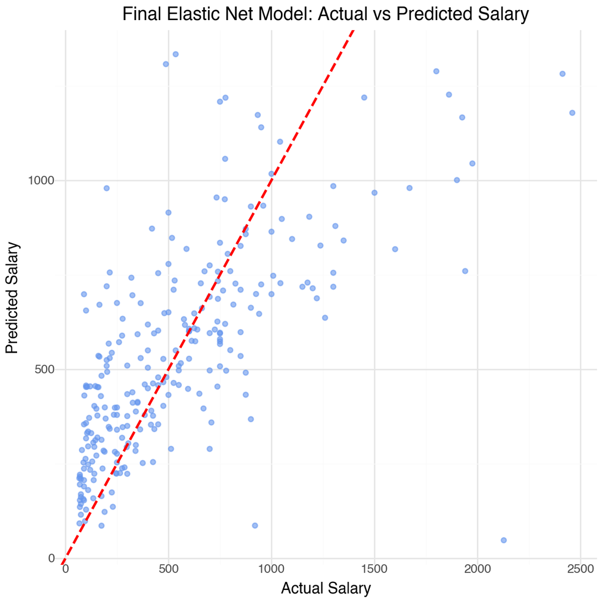

Final Elastic Net Model: Actual vs Predicted Salary

```python
from sklearn.metrics import mean_squared_error
from plotnine import ggplot, aes, geom_point, geom_abline, labs, theme_minimal, theme, element_text



final_model = Pipeline([
    ("preprocessing", ct),
    ("elastic_net", ElasticNet(alpha=1.0, l1_ratio=0.4, max_iter=10000))
])

# Fit model on full dataset
final_model.fit(X, y)

# Predict on full dataset
y_pred = final_model.predict(X)

# Compute MSE
final_mse = mean_squared_error(y, y_pred)
print(f"Final Model MSE: {final_mse:.3f}")

# Create DataFrame for plotting
plot_df = pd.DataFrame({
    "Actual": y,
    "Predicted": y_pred
})

# ggplot visualization
(
    ggplot(plot_df, aes(x="Actual", y="Predicted"))
    + geom_point(alpha=0.6, color="cornflowerblue")
    + geom_abline(intercept=0, slope=1, color="red", linetype="dashed", size=1)
    + labs(
        title="Final Elastic Net Model: Actual vs Predicted Salary",
        x="Actual Salary",
        y="Predicted Salary"
    )
    + theme_minimal()
    + theme(
        figure_size=(6, 6),
        plot_title=element_text(size=13, weight="bold"),
        axis_title=element_text(size=11)
    )
)
```

This result reinforces the advantage of the Elastic Net approach, which combines the strengths of both Ridge and LASSO regularization; balancing bias reduction with variable selection to produce a stable and interpretable model.